# Statistical Report: Gapminder data set

Eldho Paul

2024-01-06

## Exploration

Gapminder Foundation is a non-profit venture registered in Stockholm, Sweden, that promotes sustainable global development and achievement of the United Nations Millennium Development Goals by increased use and understanding of statistics and other information about social, economic, and environmental development at local, national, and global levels.

The Gapminder data set that is in use for this report is on life expectancy, GDP per capita, and population by country.

### General summary

```
##         country        continent        year         lifeExp
##  Afghanistan:  12   Africa  :624   Min.   :1952   Min.   :23.60
##  Albania    :  12   Americas:300   1st Qu.:1966   1st Qu.:48.20
##  Algeria    :  12   Asia    :396   Median :1980   Median :60.71
##  Angola     :  12   Europe  :360   Mean   :1980   Mean   :59.47
##  Argentina  :  12   Oceania : 24   3rd Qu.:1993   3rd Qu.:70.85
##  Australia  :  12                  Max.   :2007   Max.   :82.60
##  (Other)    :1632
##       pop              gdpPercap
##  Min.   :6.001e+04   Min.   :   241.2
##  1st Qu.:2.794e+06   1st Qu.:  1202.1
##  Median :7.024e+06   Median :  3531.8
##  Mean   :2.960e+07   Mean   :  7215.3
##  3rd Qu.:1.959e+07   3rd Qu.:  9325.5
##  Max.   :1.319e+09   Max.   :113523.1
##
```

### Continental summary

```
## # A tibble: 5 × 4
##   continent Mean_LifeExp Median_LifeExp StdDev_LifeExp
##   <fct>            <dbl>          <dbl>          <dbl>
## 1 Africa            48.9           47.8           9.15
## 2 Americas          64.7           67.0           9.35
## 3 Asia              60.1           61.8          11.9
## 4 Europe            71.9           72.2           5.43
## 5 Oceania           74.3           73.7           3.80
```

### Life expectancy data distriibution

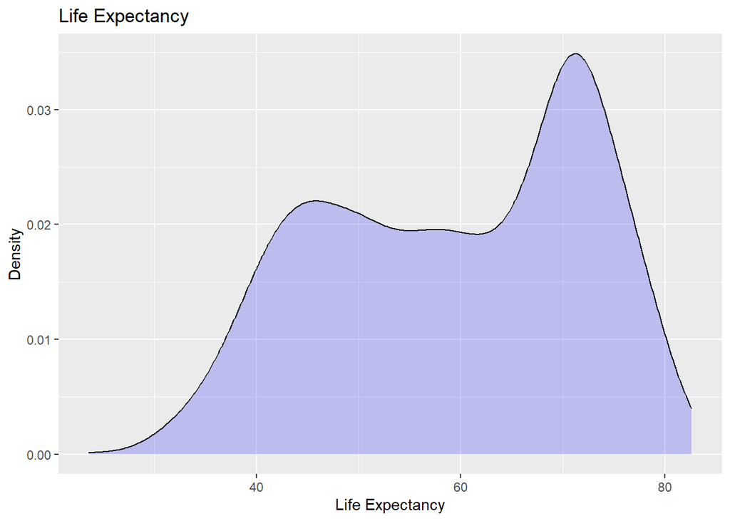

## Independent T-Test

### Assumptions

Normality: The life expectancy data for both Ireland and Switzerland should be approximately normally distributed.

Homogeneity of Variances: The variances of life expectancies in Ireland and Switzerland is roughly equal.

Independence of Observations: The life expectancy data for Ireland is independent of the data for Switzerland.

Scale of Measurement: The life expectancy is measured at an interval or ratio scale.

Random Sampling: The population of Ireland and Switzerland has an equal chance of being included in the sample.

### Density Plot

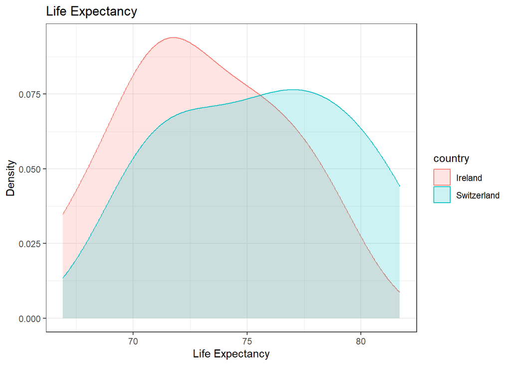

### life expectancy SD & Var

```
## # A tibble: 2 × 3
##   country     sd_lifeExp var_lifeExp
##   <fct>            <dbl>       <dbl>
## 1 Ireland           3.62        13.1
## 2 Switzerland       4.01        16.1
```

### T-test

```
##
##  Welch Two Sample t-test
##
## data:  lifeExp by country
## t = -1.6337, df = 21.77, p-value = 0.05835
## alternative hypothesis: true difference in means between group Ireland and group Switzerland is less than 0
## 95 percent confidence interval:
##       -Inf 0.1313697
## sample estimates:
##     mean in group Ireland mean in group Switzerland
##                  73.01725                  75.56508
```

### Reflection

Seeing from the results above, it can be said that null hypothesis cannot be rejected as our assumption is not statistically significant and that it might as well be that they might as well have almost the same mean life expectancy.

## Paired T-Test

### Assumptions

Paired Observations: The data must consist of matched pairs — in this case, life expectancy values in African countries in 1957 paired with their corresponding values in 2007.

Normality of Differences: The differences in life expectancy between the two years (2007 - 1957) for each African country is approximately normally distributed.

Independence of Pairs: Each pair (country’s life expectancy in 1957 and 2007) is independent of the other pairs.

Scale of Measurement: The life expectancy is measured on an interval or ratio scale.

Random Sampling: The African countries included does represent a random sample of a larger population.

### Density Plot

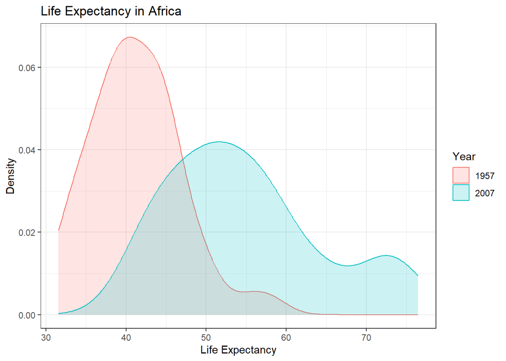

### life expectancy SD & Var:

```
## # A tibble: 2 × 3
##    year sd_lifeExp var_lifeExp
##   <int>      <dbl>       <dbl>
## 1  1957       5.62        31.6
## 2  2007       9.63        92.8
```

### Paired t-test

```
##
##  Paired t-test
##
## data:  lifeExp by year
## t = 11.381, df = 51, p-value = 1.308e-15
## alternative hypothesis: true mean difference is not equal to 0
## 95 percent confidence interval:
##  11.15125 15.92814
## sample estimates:
## mean difference
##        13.53969
```

## Anova

### Assumptions

Normality: The life expectancy data for each continent (Americas, Europe, Asia) is approximately normally distributed.

Homogeneity of Variances: The variances of life expectancy across these continents is similar.

Independence of Observations: The life expectancy data for each continent is independent of the others.

Random Sampling: The data for each continent does represent a random sample from the respective continental populations.

Interval or Ratio Level Data: The life expectancy data is measured at an interval or ratio scale.

Independence of Groups: The groups (continents) is mutually exclusive.

### Mean life expectancy

```
## # A tibble: 3 × 2
##   continent Mean_life
##   <fct>         <dbl>
## 1 Asia           70.7
## 2 Americas       73.6
## 3 Europe         77.6
```

### Research question

Is the life expectancy in these three continents different?

### Hypothesis

H0: Mean life expectancy is the same H1: Mean life expectancy is not the same

```
## # A tibble: 3 × 3
##   continent    sd variance
##   <fct>     <dbl>    <dbl>
## 1 Americas   9.35     87.3
## 2 Asia      11.9     141.
## 3 Europe     5.43     29.5
```

### Anova result

```
##             Df Sum Sq Mean Sq F value   Pr(>F)
## continent    2  755.6   377.8   11.63 3.42e-05 ***
## Residuals   85 2760.3    32.5
## ---
## Signif. codes:  0 '***' 0.001 '**' 0.01 '*' 0.05 '.' 0.1 ' ' 1
```

### Tukey comparison

```
##   Tukey multiple comparisons of means
##     95% family-wise confidence level
##
## Fit: aov(formula = lifeExp ~ continent, data = .)
##
## $continent
##                      diff        lwr        upr     p adj
## Asia-Americas   -2.879635 -6.4839802  0.7247099 0.1432634
## Europe-Americas  4.040480  0.3592746  7.7216854 0.0279460
## Europe-Asia      6.920115  3.4909215 10.3493088 0.0000189
```

## Linear regression

### Scatter Plot

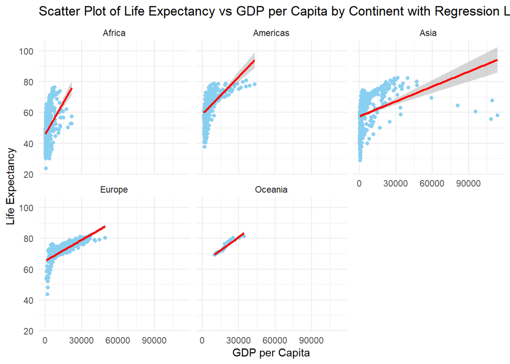

### Scatter Plot(EU)

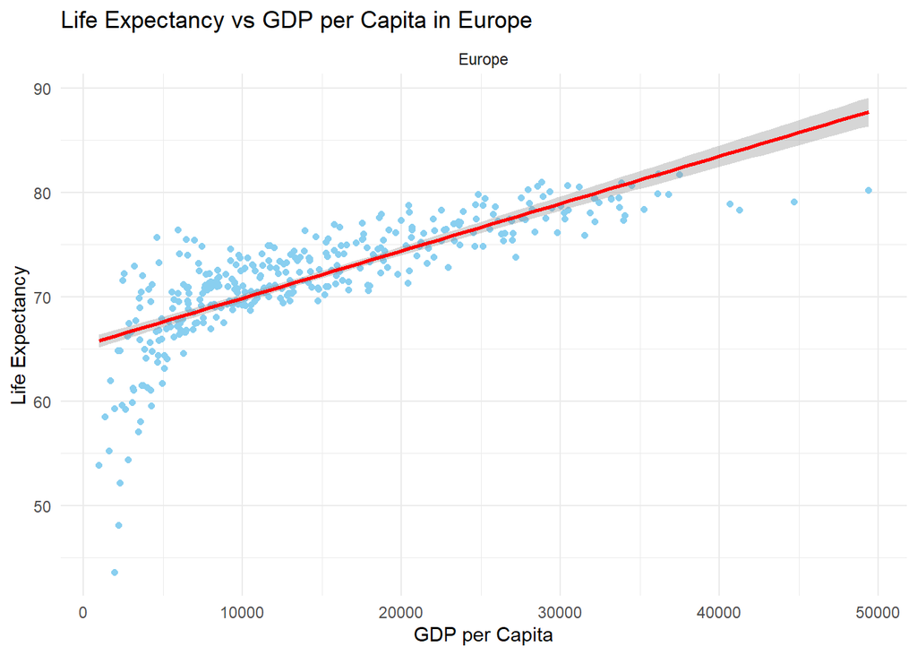

### Linear model result

```
##
## Call:
## lm(formula = gdpPercap ~ lifeExp, data = europe_data)
##
## Residuals:
##      Min       1Q   Median       3Q      Max
## -14903.2  -3741.8   -852.6   3218.5  25571.4
##
## Coefficients:
##              Estimate Std. Error t value Pr(>|t|)
## (Intercept) -82198.22    4100.01  -20.05   <2e-16 ***
## lifeExp       1344.41      56.86   23.64   <2e-16 ***
## ---
## Signif. codes:  0 '***' 0.001 '**' 0.01 '*' 0.05 '.' 0.1 ' ' 1
##
## Residual standard error: 5853 on 358 degrees of freedom
## Multiple R-squared:  0.6096, Adjusted R-squared:  0.6085
## F-statistic: 559.1 on 1 and 358 DF,  p-value: < 2.2e-16
```

### Reflection

The null hypothesis is not statistically significant( p<2e-16) and hence is rejected. We find a relation between both the variables and we can agree the slope seen in the linear model.